# RDA candidates detection new variables

Thomas Francisco

2024-04-30

**Candidate selection: Redundancy analysis(RDA)**

In this script, we will perform an RDA (not accounting for population structure): Redundancy analysis are multivariate canonical analysis that are halfway between PCA and multiple regression. Indeed, it performed an analysis similar to a multiple regression, the major differences is that RDA perform a multiple regression with a matrix of response variables and not just one. It’s a canonical analysis because this analysis will create canonical axis similar to a PCs. The explanation of this analysis is that we first performed linear regressions between the explanatory variables and the responses variables then we performed on the fitted values (result of the linear regressions) a PCA to create the canonical axis (RDA axis) to reduce the number of dimensions. These canonical axis are the results of the linear combinations of the explanatory variables. It’s like a PCA and a multiple regression because in the end, we have results similar to PCA but with fitted values enabling us to extrapolate the model (following a linear relationship). In the end, RDA is a multivariate analysis following linear hypothesis that cannot be corrected for population structure (see pRDA for correction) Sources: Legendre and Legendre 2012, Capblancq 2021, workshop redundancy analysis of the Quebec centre for Biodiversity Science (https://r.qcbs.ca/workshop10/book-en/redundancy-analysis.html)

```
1. Loading data
```

Data is coming from the script variance_partitioning where the different variables of interest were gather in one data frame. The genomic matrix is the allelic frequencies at the population level (29 pop) on the imputed dataset (475 indiv, 8616 SNPs) with MAF correction

```r
#genomic data
load("C:/Users/tfrancisco/Documents/Thèse/Data/Espèces/Taxus_baccata/genetic_new/data_allelic_frequencies_29pop_adapcon_gentree_475_8616.Rdata")

genomic_matrix <- data_allelic_frequencies_29pop_adapcon_gentree_475_8616

#climatic/structure/IBD
load("C:/Users/tfrancisco/Documents/Thèse/Data/Espèces/Taxus_baccata/GEA_new_var/variance_partitioning/Climatic_data_RDA_pRDA.Rdata")
```

```
2. Performing the RDA
```

We perform the Redundancy analysis with the genomic matrix corrected for MAF and the scaled climatic variables of interest

```r
#model
RDA_env <- rda(formula = genomic_matrix ~  Annual_Tc+Diurnal_range_Tc+Tc_Seasonality+Tc_driest_quarter+Annual_P+P_Seasonality, data = Climatic_data_RDA_pRDA, scale=F)

RsquareAdj(RDA_env)
```

```
## $r.squared
## [1] 0.3262662
##
## $adj.r.squared
## [1] 0.1425206
```

```r
#other analysis to test the model
#summary(RDA_env)
#significativity of the model
#anova.cca(RDA_env)
#test the significativity of the axis and the climatic variables using permutation
#anova.cca(RDA_env, step = 1000, by = "axis")
#anova.cca(RDA_env, step = 1000, by = "term")
```

Interpretation: The r^2 of the climatic variable on the genomic matrix is quite important suggesting that performing GEA on this dataset can be interesting because a important number of candidates could be identified.

Then, we need to perform the candidate selection on this models. To do this, we will follow the procedure in Capblancq et al. 2021 and we will identified outliers based on their position along a distribution of Mahalanobis distances estimated between each locus and the center of the RDA space using a certain number of axes (K).

First, we need to select the number of ordination axis (RDA axis) that we will retains

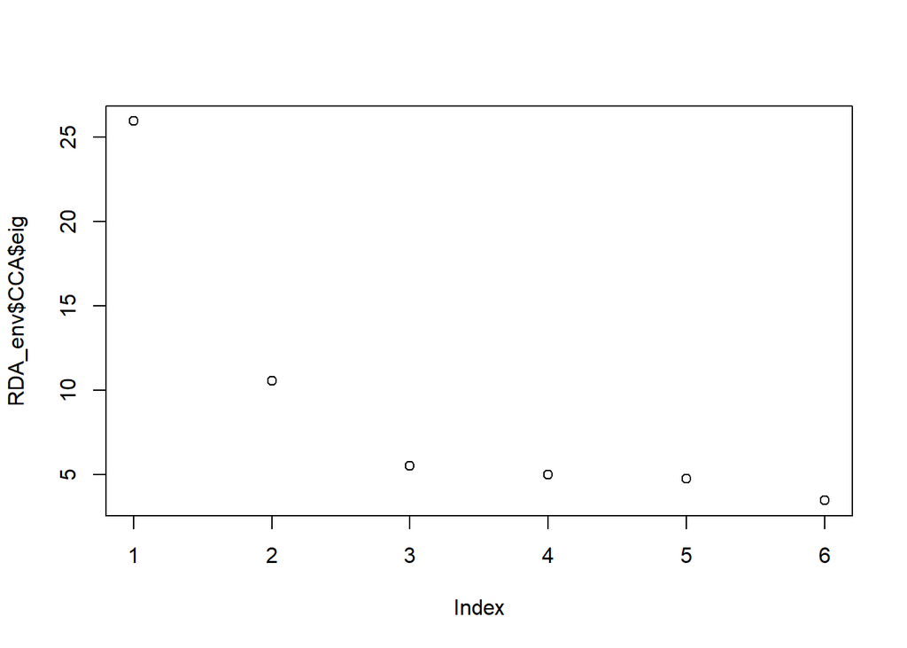

```r
#screeplot
plot(RDA_env$CCA$eig, option="screeplot")
```

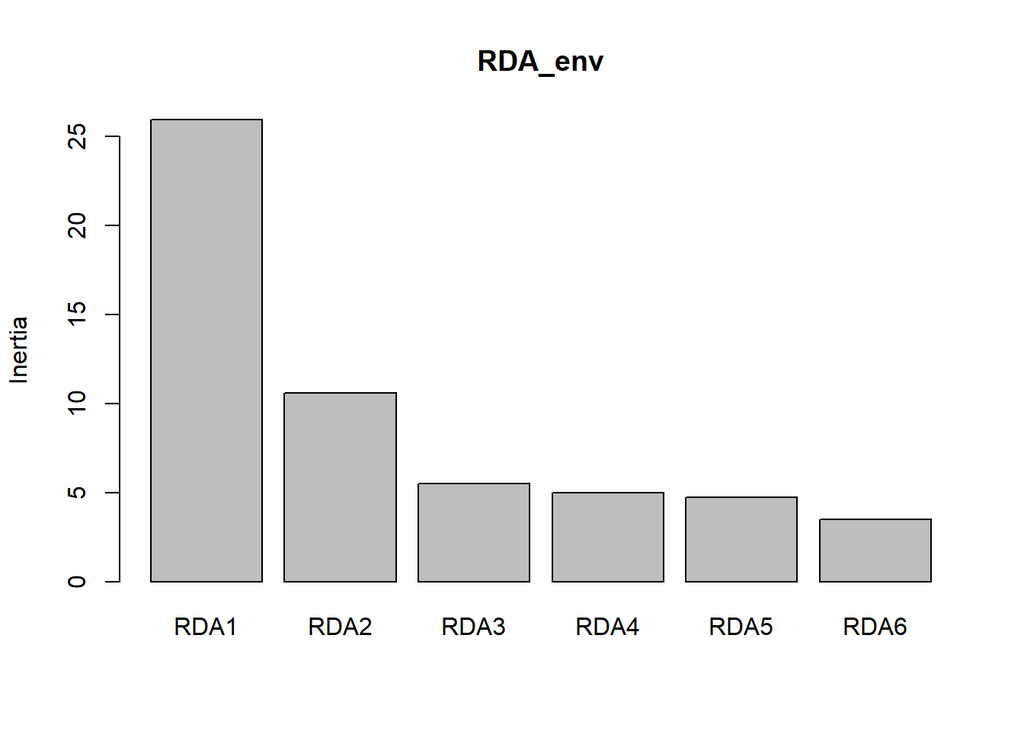

```r
#in hist
screeplot_RDA<- screeplot(RDA_env)
```

```r
#explained variance along each RDA axis
RDA_env$CCA$eig*100/sum(RDA_env$CCA$eig)
```

```
##      RDA1      RDA2      RDA3      RDA4      RDA5      RDA6
## 46.957418 19.146281  9.968377  9.031111  8.598810  6.298003
```

Interpretation: based on this, we will keep the 2 first RDA axis to perform the candidates detection

One interesting things with RDA is that we can plot in the same space the populations (or individuals or genotype depending on our study), the loci and the climatic variables. Here, we represented into the RDA space, the populations and the climatic variable in a biplot.

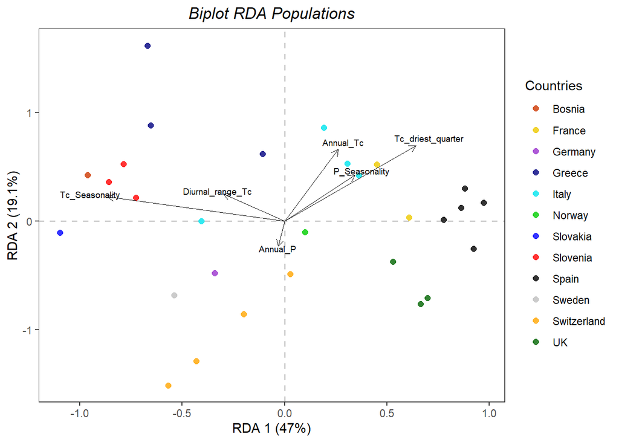

```r
#score along the 2 first RDA axis
score_climatic_var <- as.data.frame(scores(RDA_env, choices=c(1:2), display="bp"))
#Score_population <- data.frame(RDA_env$CCA$u[,c(1,2)])
score_pop_var <- as.data.frame(scores(RDA_env, choices=c(1:2), display="sites",scaling="none"))

#meta_data
meta_data_pop <- read.csv("C:/Users/tfrancisco/Documents/Thèse/Data/Espèces/Taxus_baccata/Populations/taxus_sample_29pop.csv",h=T,sep=";",dec=",")

#alphabetic order
meta_data_pop_order <- meta_data_pop[order(meta_data_pop$Population),]

#merge for country info
Score_population_bis <- rownames_to_column(score_pop_var,"Population")
score_with_country_info <- merge(Score_population_bis,meta_data_pop_order[,c(1,2)],"Population")
score_with_country_info$Country <- as.factor(score_with_country_info$Country)

#explained variance along each RDA axis
explained_variance <- data.frame(RDA_env$CCA$eig)*100/sum(RDA_env$CCA$eig) # variance of each axis*100 divided by the sum of all the explained variance for all axis

explained_variance_round <- round(explained_variance$RDA_env.CCA.eig,digits=1)


group_palette <- c("Bosnia"="orangered3", "France"="gold2","Germany"= "darkorchid3", "Greece"="navyblue", "Italy"="turquoise2", "Norway"="green3", "Slovakia"="blue", "Slovenia"="red", "Spain"="black", "Sweden"="gray", "Switzerland"="orange", "UK"="darkgreen")


##Biplot with populations and climatic variables along the 2 first RDA axis
biplot_populations <- ggplot() +
  geom_hline(yintercept = 0, linetype = "dashed", color = gray(0.80), size = 0.6) +
  geom_vline(xintercept = 0, linetype = "dashed", color = gray(0.80), size = 0.6) +
  geom_point(data = score_with_country_info, aes(x = RDA1 * 3, y = RDA2 * 3, colour = Country), size = 2, alpha = 0.8) +
  geom_segment(data = score_climatic_var, aes(xend = RDA1, yend = RDA2, x = 0, y = 0), colour = "black", size = 0.15, linetype = 1, arrow = arrow(length = unit(0.02, "npc"))) +
  geom_text(data = score_climatic_var, aes(x=1.1*RDA1, y=1.1*RDA2, label = row.names(score_climatic_var)), size = 2.5)+
  xlab(paste0("RDA 1 (",explained_variance_round[1],"%)")) +
  ylab(paste0("RDA 2 (",explained_variance_round[2],"%)")) +
  ggtitle("Biplot RDA Populations") +
  scale_color_manual(name = "Countries", values = group_palette, labels = levels(score_with_country_info$Country)) +
  theme_bw(base_size = 11) +
  theme(legend.position="right", panel.grid = element_blank(), strip.text = element_text(size=11),plot.title = element_text(hjust = 0.5,color = "Black",face="italic"))+
  labs(color = "Country")

 print(biplot_populations)
```

Interpretation: We can see that populations more in altitude/in the East are on the left along the first RDA axis and populations in less altitute with warmer temperature are on the right -> RDA1 seems to be a continentality/altitudinal gradient. RDA2 seems to separate the populations based on their precipitation.

```
3. Identification of outliers
```

The next step is to perform the genome scan procedure to calculate the Mahalanobis distance and then calculate qvalues and pvalues associated to this distance that will be used as threshold for candidates selection.

We used the rdadapt function from Capblancq et al 2021:

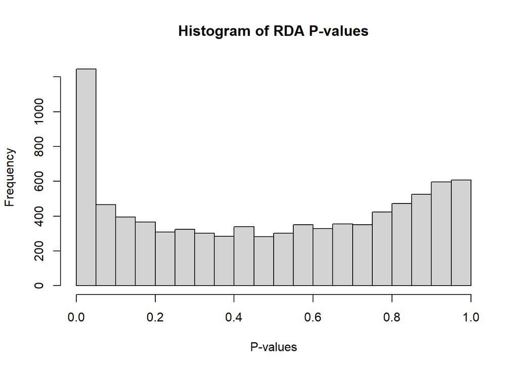

```r
rdadapt<-function(rda,K)
{
  zscores<-rda$CCA$v[,1:as.numeric(K)]
  resscale <- apply(zscores, 2, scale)
  resmaha <- covRob(resscale, distance = TRUE, na.action= na.omit, estim="pairwiseGK")$dist
  lambda <- median(resmaha)/qchisq(0.5,df=K)
  reschi2test <- pchisq(resmaha/lambda,K,lower.tail=FALSE)
  qval <- qvalue(reschi2test)
  q.values_rdadapt<-qval$qvalues
  return(data.frame(p.values=reschi2test, q.values=q.values_rdadapt))
}

#Perform the function to calculate the mahalanobis distance and then pvalues/qvalues
genome_scan_RDA <- rdadapt(RDA_env,K=2) #the K is equal to the number of RDA axis that we want to use for the selection

#save the pvalues for each snp for retaining SNPs in LD with the greater signal in the outliers identification script
pvalues_RDA_snp <- data.frame(snp_names=colnames(genomic_matrix),pvalues= genome_scan_RDA$p.values)
save(pvalues_RDA_snp,file="C:/Users/tfrancisco/Documents/Thèse/Data/Espèces/Taxus_baccata/genetic_new/GEA_new_var/pvalues_RDA_snp.Rdata" )

load("C:/Users/tfrancisco/Documents/Thèse/Data/Espèces/Taxus_baccata/genetic_new/GEA_new_var/pvalues_RDA_snp.Rdata")
write_xlsx(pvalues_RDA_snp,"C:/Users/tfrancisco/Documents/Thèse/Data/Espèces/Taxus_baccata/genetic_new/GEA_new_var/pvalues_RDA_snp.xlsx")

#plot the distribution of pvalues
Histogram_of_Pvalues_RDA<- hist(genome_scan_RDA$p.values,
     main= "Histogram of RDA P-values",
     xlab= "P-values")
```

```
4. Selection of a threshold
```

Based on these calculations of pvalues and qvalues, we are able to perform a candidate selection:

```r
# qvalues < 0.05
thres_qvalues <- 0.05

outliers_qvalues_5perc_RDA <- data.frame(Loci = colnames(genomic_matrix)[which(genome_scan_RDA$q.values<thres_qvalues)], p.value = genome_scan_RDA$q.values[which(genome_scan_RDA$q.values<thres_qvalues)], contig = unlist(lapply(strsplit(colnames(genomic_matrix)[which(genome_scan_RDA$q.values<thres_qvalues)], split = "_"), function(x) x[1])))

nrow(outliers_qvalues_5perc_RDA)
```

```
## [1] 211
```

```r
# qvalues < 0.10
thres_qvalues <- 0.10

outliers_qvalues_10perc_RDA <- data.frame(Loci = colnames(genomic_matrix)[which(genome_scan_RDA$q.values<thres_qvalues)], p.value = genome_scan_RDA$q.values[which(genome_scan_RDA$q.values<thres_qvalues)], contig = unlist(lapply(strsplit(colnames(genomic_matrix)[which(genome_scan_RDA$q.values<thres_qvalues)], split = "_"), function(x) x[1])))

nrow(outliers_qvalues_10perc_RDA)
```

```
## [1] 373
```

```r
#threshold pvalues < 0.05 with Bonferonni correction
thres_pvalues <- 0.05/length(genome_scan_RDA$p.values)

outliers_pvalues <- data.frame(Loci = colnames(genomic_matrix)[which(genome_scan_RDA$p.values<thres_pvalues)], p.value = genome_scan_RDA$p.values[which(genome_scan_RDA$p.values<thres_pvalues)], contig = unlist(lapply(strsplit(colnames(genomic_matrix)[which(genome_scan_RDA$p.values<thres_pvalues)], split = "_"), function(x) x[1])))

nrow(outliers_pvalues)
```

```
## [1] 15
```

```r
#top 1%
##add colnames
#genome_scan_RDA$snp_names <- colnames(genomic_matrix)

#outliers_top1perc <- genome_scan_RDA %>%
#  arrange(p.values) %>%
#slice(1:(0.01*nrow(.))) %>%
#  as.data.frame()
```

We also perform the outlier detection based on the loadings of loci along the RDa axis to search for extreme loadings on each retained axis following Forester et al. (2018).

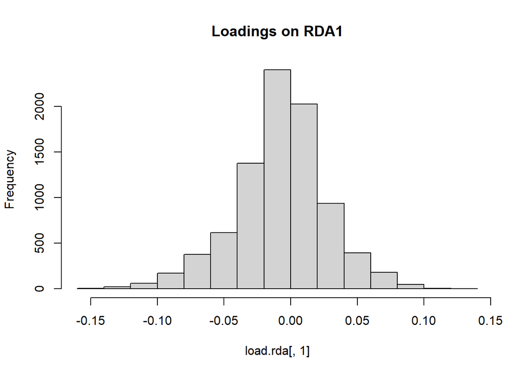

```r
load.rda <- scores(RDA_env, choices=c(1:3), display="species")

hist(load.rda[,1], main="Loadings on RDA1")
```

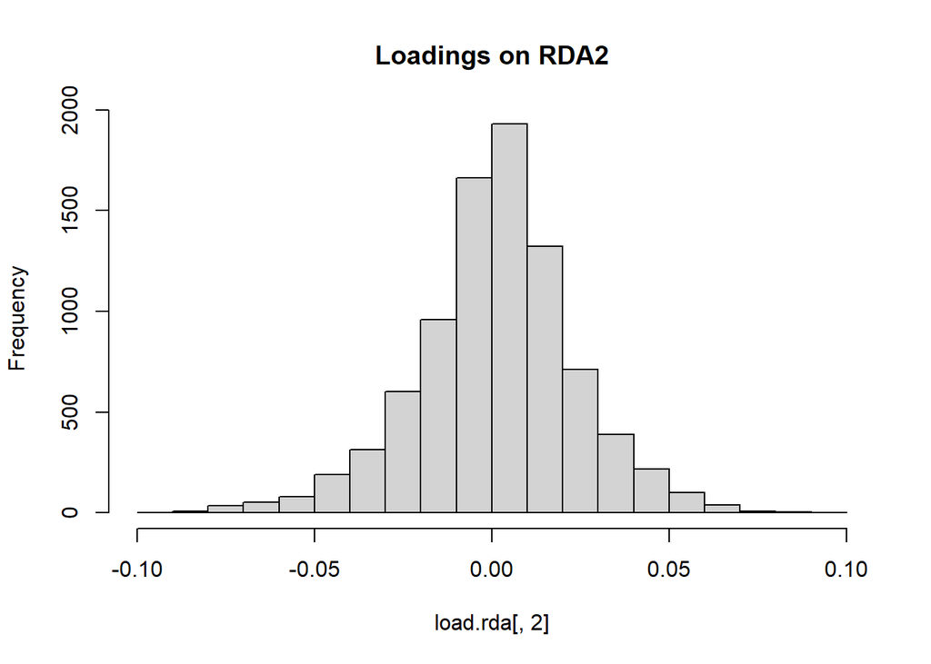

```r
hist(load.rda[,2], main="Loadings on RDA2")
```

Function from Forester et al. (2018).

```r
#function to do it
outliers_function <- function(x,z){
  lims <- mean(x) + c(-1, 1) * z * sd(x)     # find loadings +/-z sd from mean loading
  x[x < lims[1] | x > lims[2]]               # locus names in these tails
}

cand1 <- data.frame(outliers_function(load.rda[,1],3)) # 3
colnames(cand1) <- c("pvalues"); cand1$snp_names <- row.names(cand1)
cand2 <- data.frame(outliers_function(load.rda[,2],3)) # 51
colnames(cand2) <- c("pvalues"); cand2$snp_names <- row.names(cand2)

#names of the outliers
outliers_extremness <- rbind (cand1,cand2)

nrow(outliers_extremness)
```

```
## [1] 144
```

```
5. Graphic representations of the outliers:
```

We can represent the candidates and the neutral loci into the RDA space with the climatic variables:

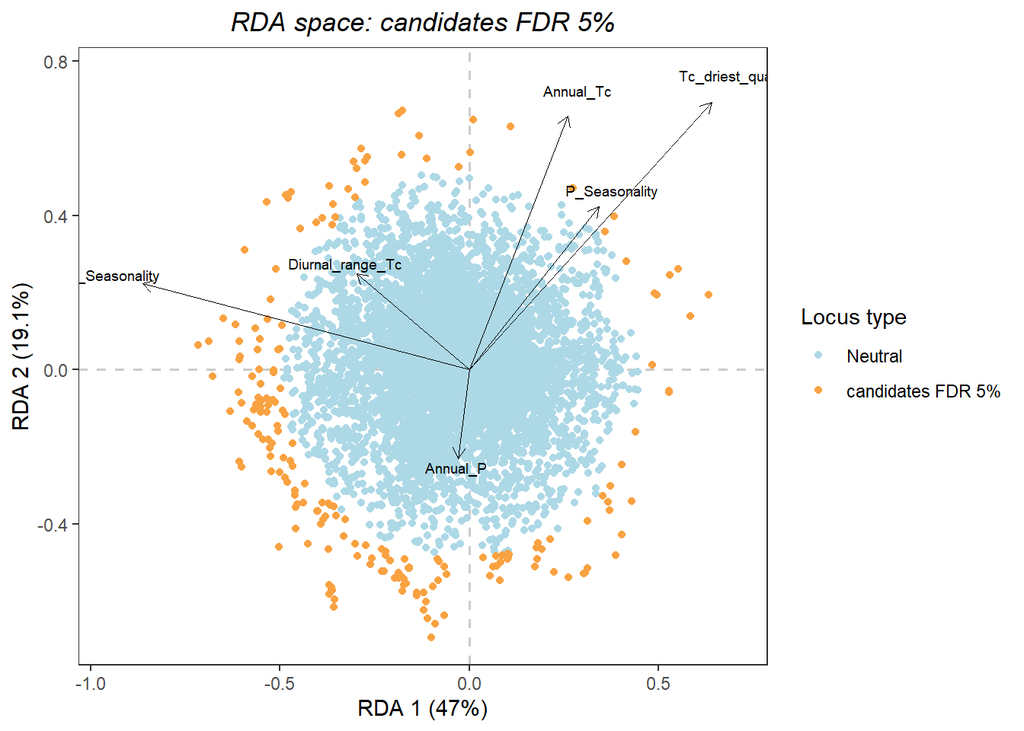

```r
score_loci <- as.data.frame(scores(RDA_env, choices=c(1:2), display="species", scaling="none"))
score_loci_outliers <- data.frame(names = row.names(score_loci), score_loci)
score_loci_outliers$FDR5 <- "Neutral"
score_loci_outliers$FDR5[score_loci_outliers$names%in%outliers_qvalues_5perc_RDA$Loci] <- "candidates FDR 5%"
score_loci_outliers$FDR5 <- factor(score_loci_outliers$FDR5, levels = c("Neutral", "candidates FDR 5%"))
score_loci_outliers <- score_loci_outliers[order(score_loci_outliers$FDR5),]

#Biplot with SNPs and climatic variables along the two first RDA axis.
 biplot_outliers_RDA<- ggplot() +
  geom_hline(yintercept=0, linetype="dashed", color = gray(.80), size=0.6) +
  geom_vline(xintercept=0, linetype="dashed", color = gray(.80), size=0.6) +
  geom_point(data = score_loci_outliers, aes(x=RDA1*15, y=RDA2*15,colour=FDR5), size = 1.4) +
  geom_segment(data = score_climatic_var, aes(xend=RDA1, yend=RDA2, x=0, y=0), colour="black", size=0.15, linetype=1, arrow=arrow(length = unit(0.02, "npc"))) +
  geom_text(data = score_climatic_var, aes(x=1.1*RDA1, y=1.1*RDA2, label = row.names(score_climatic_var)), size = 2.5) +
  xlab(paste0("RDA 1 (",explained_variance_round[1],"%)")) +
  ylab(paste0("RDA 2 (",explained_variance_round[2],"%)")) +
   ggtitle("RDA space: candidates FDR 5%") +
  guides(color=guide_legend(title="Locus type")) +
  scale_color_manual(values = c("lightblue", "#F9A242FF")) +
  theme_bw(base_size = 11) +
  theme(legend.position="right", panel.grid = element_blank(), strip.text = element_text(size=11),plot.title = element_text(hjust = 0.5,color = "Black",face="italic"))

 print(biplot_outliers_RDA)
```

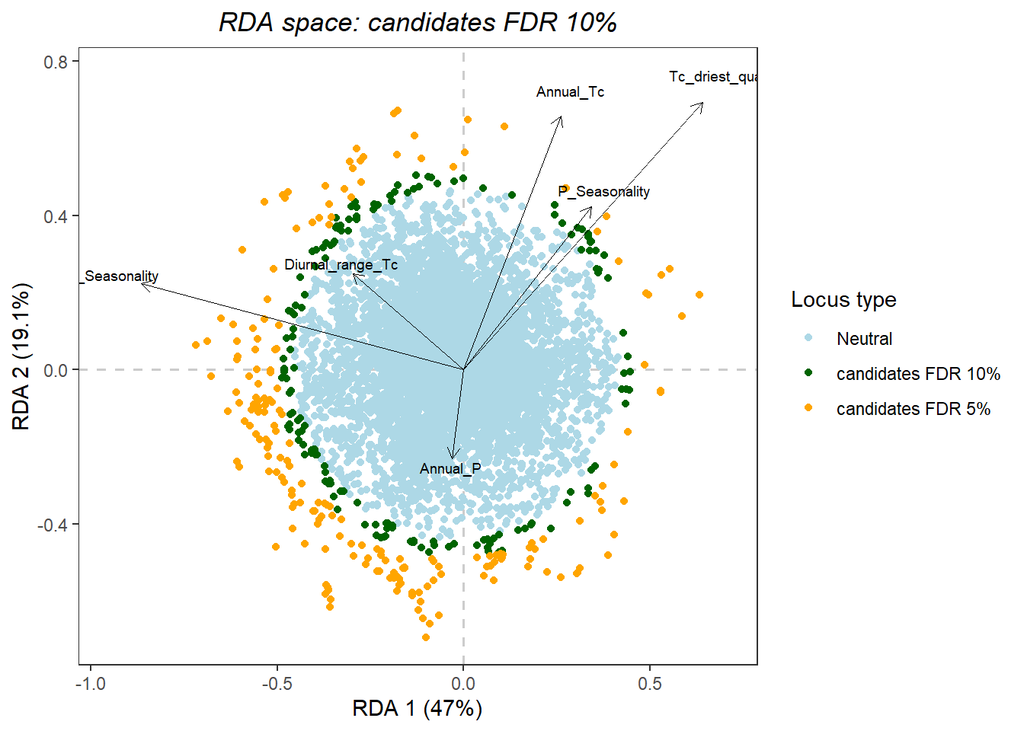

[output not shown]

```r
score_loci <- as.data.frame(scores(RDA_env, choices=c(1:2), display="species", scaling="none"))
score_loci_outliers <- data.frame(names = row.names(score_loci), score_loci)
score_loci_outliers$FDR5_10 <- "Neutral"
score_loci_outliers$FDR5_10[score_loci_outliers$names%in%outliers_qvalues_10perc_RDA$Loci] <- "candidates FDR 10%"
score_loci_outliers$FDR5_10[score_loci_outliers$names%in%outliers_qvalues_5perc_RDA$Loci] <- "candidates FDR 5%"
score_loci_outliers$FDR5_10 <- factor(score_loci_outliers$FDR5_10, levels = c("Neutral","candidates FDR 10%","candidates FDR 5%"))
score_loci_outliers <- score_loci_outliers[order(score_loci_outliers$FDR5_10),]

#Biplot with SNPs and climatic variables along the two first RDA axis including the less conservative threshold
 biplot_outliers_RDA_LC<- ggplot() +
  geom_hline(yintercept=0, linetype="dashed", color = gray(.80), size=0.6) +
  geom_vline(xintercept=0, linetype="dashed", color = gray(.80), size=0.6) +
  geom_point(data = score_loci_outliers, aes(x=RDA1*15, y=RDA2*15,colour=FDR5_10), size = 1.4) +
  geom_segment(data = score_climatic_var, aes(xend=RDA1, yend=RDA2, x=0, y=0), colour="black", size=0.15, linetype=1, arrow=arrow(length = unit(0.02, "npc"))) +
  geom_text(data = score_climatic_var, aes(x=1.1*RDA1, y=1.1*RDA2, label = row.names(score_climatic_var)), size = 2.5) +
  xlab(paste0("RDA 1 (",explained_variance_round[1],"%)")) +
  ylab(paste0("RDA 2 (",explained_variance_round[2],"%)")) +
   ggtitle("RDA space: candidates FDR 10%") +
  guides(color=guide_legend(title="Locus type")) +
  scale_color_manual(values = c("lightblue","darkgreen","orange")) +
  theme_bw(base_size = 11) +
  theme(legend.position="right", panel.grid = element_blank(), strip.text = element_text(size=11),plot.title = element_text(hjust = 0.5,color = "Black",face="italic"))

 print(biplot_outliers_RDA_LC)
```

We want to see if the candidates from extremness and the FDR 5% are similar:

```r
colnames(outliers_qvalues_5perc_RDA)= c( "snp_names","p.value","contig")
#overlapping extremeness 2.5 and qvalues < 0.05
overlapping <- merge(outliers_extremness,outliers_qvalues_5perc_RDA,"snp_names")
```

Interpretation: 137 out of the 144 candidates identified by extremeness are overlapping with the 211 retained by a qvalues threshold of 0.05.

We will use FDR as a threshold to identified snp. We save the candidates identified by FDR thresholds:

```
- FDR 5% candidates:
```

```r
outliers_RDA_FDR5perc_T_Adapcon_gentree <- outliers_qvalues_5perc_RDA[,-3]

#write_xlsx(outliers_RDA_FDR5perc_T_Adapcon_gentree,"C:/Users/tfrancisco/Documents/Thèse/Results/species/taxus/GEA/outliers/outliers_RDA_FDR5perc_T_Adapcon_gentree.xlsx")
save(outliers_RDA_FDR5perc_T_Adapcon_gentree, file="C:/Users/tfrancisco/Documents/Thèse/Results/species/taxus/GEA_new_var/outliers/outliers_RDA_FDR5perc_T_Adapcon_gentree.Rdata")
```

```
- FDR 10% candidates:
```

```r
outliers_RDA_FDR10perc_T_Adapcon_gentree <- outliers_qvalues_10perc_RDA[,-3]

#write_xlsx(outliers_RDA_FDR10perc_T_Adapcon_gentree,"C:/Users/tfrancisco/Documents/Thèse/Results/species/taxus/GEA/outliers/outliers_RDA_FDR5perc_T_Adapcon_gentree.xlsx")
save(outliers_RDA_FDR10perc_T_Adapcon_gentree, file="C:/Users/tfrancisco/Documents/Thèse/Results/species/taxus/GEA_new_var/outliers/outliers_RDA_FDR10perc_T_Adapcon_gentree.Rdata")
```